# errors

### The main aim of this study was to acknowledge errors in this dataset to that extend that we will be able to choose a right volume threshold and other related restraints for our clustering analysis

### A significant number of errors was found in this dataset. Initially, we tried to identify all errors throughout the dataset. Subsequently, we tried to determine whether the errors are related to only inner or surface parts of the sculpture.

### We were able to find multiple errors most likely related to the very small size of particles that could have led to both scanning errors and following errors during the preprocessing of the scans.

### Two main data related issues were encountered in this dataset. First error was linked to the shape in terms of violating fixed range of values between 0 and 1 for anisotropy, elongation and flatness. Second issue represents so called outliers that are any values distant from the other values in the dataset. In our case should be noted that most natural materials, such as sands or silts, do not feature such extreme particle shapes (elongation and flatness features), as these tend to break in nature, and evolve into smaller, more regular fragments (https://www.sciencedirect.com/science/article/pii/S0032591021009785#fig0040)

```python
import pandas as pd
import numpy as np
import matplotlib.pyplot as plt
import seaborn as sns
import scipy.stats as stats
sns.set()
```

```python
all_particles = pd.read_csv('C:/Users/hamro/Desktop/final_table.csv')
```

# 1. All atributes

### As we can see below that the minimum values for anisotropy, elongation and flatness are clearly erroneous since all these characteristics are used for describing the morfology of the particles, ranging between 0 and 1 (T. ZinggBeitrag Zur SchotteranalyseETH Zurich, Switzerland (1935))

### we can also identify outliers using the following formulas for the lower and upper boundary respectively: lower= Q1 - (1.5*IQR), upper=Q3+(1.5*IQR), where Q1=first quartile, Q3=third quartile and IQR=interquartile range.

```python
all_particles.describe()
```

|  | Volume3d (mm^3) | BaryCenterX (mm) | BaryCenterY (mm) | BaryCenterZ (mm) | Anisotropy | Elongation | Flatness | VoxelFaceArea (mm^2) | Sphericity |
| --- | --- | --- | --- | --- | --- | --- | --- | --- | --- |
| count | 102515.000000 | 102515.000000 | 102515.000000 | 102515.000000 | 102515.000000 | 102515.000000 | 102515.000000 | 102515.000000 | 102515.000000 |
| mean | 0.009713 | -1246.522981 | -1246.863327 | -1672.536396 | 0.676258 | 0.438560 | 0.328198 | 0.146898 | 0.658045 |
| std | 0.361543 | 4.688294 | 7.830213 | 25.611063 | 0.416351 | 0.406608 | 0.508212 | 1.638454 | 0.080128 |
| min | 0.000007 | -1262.260000 | -1269.460000 | -1731.770000 | -1.000000 | -1.000000 | -1.000000 | 0.002151 | 0.167262 |
| 25% | 0.000048 | -1249.780000 | -1252.495000 | -1691.630000 | 0.611283 | 0.292913 | 0.179971 | 0.009320 | 0.614133 |
| 50% | 0.000170 | -1246.460000 | -1246.840000 | -1672.400000 | 0.772373 | 0.499862 | 0.447890 | 0.022224 | 0.659861 |
| 75% | 0.000618 | -1243.100000 | -1241.280000 | -1654.175000 | 0.904540 | 0.692323 | 0.655831 | 0.055918 | 0.707018 |
| max | 91.752900 | -1233.450000 | -1225.980000 | -1617.670000 | 1.000000 | 0.999980 | 1.000000 | 244.736000 | 0.805997 |

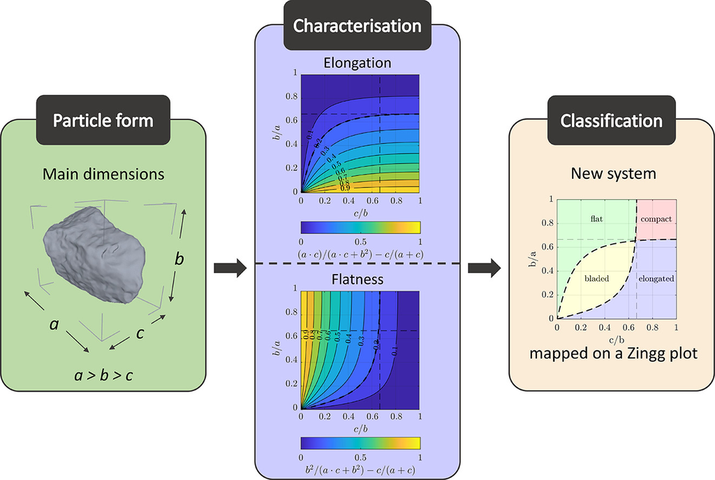

### this picture was adapted from: (https://www.sciencedirect.com/science/article/pii/S0032591021009785#fig0040, 18.9.2022)

## Anisotropy, Elongation, Flatness: error related to -1 value

## shape features including Anisotropy, Elongation, Flatness

### throughout the dataset the error related to the extreme value -1 always appear for features including anisotropy, elongation and flatness at the same time on top of that there are other particles with flatness equal to -1 but in relation to them anisotropy and elongation are not equal to -1.

```python
all_particles[(all_particles['Anisotropy'] == -1) & (all_particles['Elongation'] == -1) & (all_particles['Flatness'] == -1)].describe()
```

|  | Volume3d (mm^3) | BaryCenterX (mm) | BaryCenterY (mm) | BaryCenterZ (mm) | Anisotropy | Elongation | Flatness | VoxelFaceArea (mm^2) | Sphericity |
| --- | --- | --- | --- | --- | --- | --- | --- | --- | --- |
| count | 4.874000e+03 | 4874.000000 | 4874.000000 | 4874.000000 | 4874.0 | 4874.0 | 4874.0 | 4.874000e+03 | 4.874000e+03 |
| mean | 6.786470e-06 | -1246.341161 | -1246.710796 | -1676.098182 | -1.0 | -1.0 | -1.0 | 2.150700e-03 | 8.059973e-01 |
| std | 4.379610e-19 | 4.752394 | 8.122677 | 24.321859 | 0.0 | 0.0 | 0.0 | 2.220674e-16 | 4.896586e-14 |
| min | 6.786470e-06 | -1261.200000 | -1268.700000 | -1727.690000 | -1.0 | -1.0 | -1.0 | 2.150700e-03 | 8.059973e-01 |
| 25% | 6.786470e-06 | -1249.790000 | -1252.720000 | -1694.055000 | -1.0 | -1.0 | -1.0 | 2.150700e-03 | 8.059973e-01 |
| 50% | 6.786470e-06 | -1246.340000 | -1246.580000 | -1676.670000 | -1.0 | -1.0 | -1.0 | 2.150700e-03 | 8.059973e-01 |
| 75% | 6.786470e-06 | -1242.930000 | -1240.835000 | -1660.170000 | -1.0 | -1.0 | -1.0 | 2.150700e-03 | 8.059973e-01 |
| max | 6.786470e-06 | -1233.730000 | -1227.140000 | -1618.210000 | -1.0 | -1.0 | -1.0 | 2.150700e-03 | 8.059973e-01 |

```python
all_minus_ones.describe()
```

```
count      10.0
mean     4874.0
std         0.0
min      4874.0
25%      4874.0
50%      4874.0
75%      4874.0
max      4874.0
dtype: float64
```

```python
all_particles_count = all_particles.shape[0]
anisotropy_minus_1 = all_particles[all_particles['Anisotropy'] < 0]['Anisotropy']
percentage_anisotropy_minus_one = len(anisotropy_minus_1)/all_particles_count*100
print(f"anisotropy(-1): {percentage} % of all particles")
```

```
anisotropy(-1): 4.754426181534409 % of all particles
```

```python
anisotropy_minus_1.describe()
```

```
count    4874.0
mean       -1.0
std         0.0
min        -1.0
25%        -1.0
50%        -1.0
75%        -1.0
max        -1.0
Name: Anisotropy, dtype: float64
```

```python
all_particles.columns
```

```
Index(['Volume3d (mm^3) ', 'BaryCenterX (mm) ', 'BaryCenterY (mm) ',
       'BaryCenterZ (mm) ', 'Anisotropy', 'Elongation', 'Flatness',
       'VoxelFaceArea (mm^2)', 'Sphericity', 'SurfaceParticles'],
      dtype='object')
```

```python
# all error particles with anisotropy == -1
all_particles[all_particles['Anisotropy'] == -1]['Volume3d (mm^3) '].describe()
```

```
count    4.874000e+03
mean     6.786470e-06
std      4.379610e-19
min      6.786470e-06
25%      6.786470e-06
50%      6.786470e-06
75%      6.786470e-06
max      6.786470e-06
Name: Volume3d (mm^3) , dtype: float64
```

```python
all_particles[all_particles['Flatness'] == -1].describe()
```

|  | Volume3d (mm^3) | BaryCenterX (mm) | BaryCenterY (mm) | BaryCenterZ (mm) | Anisotropy | Elongation | Flatness | VoxelFaceArea (mm^2) | Sphericity |
| --- | --- | --- | --- | --- | --- | --- | --- | --- | --- |
| count | 10195.000000 | 10195.000000 | 10195.000000 | 10195.00000 | 10195.000000 | 10195.000000 | 10195.0 | 10195.000000 | 10195.000000 |
| mean | 0.000009 | -1246.465640 | -1246.864800 | -1672.68767 | 0.043845 | -0.478077 | -1.0 | 0.002724 | 0.790598 |
| std | 0.000003 | 4.704894 | 7.958192 | 24.89639 | 0.999087 | 0.499544 | 0.0 | 0.000732 | 0.019880 |
| min | 0.000007 | -1261.710000 | -1269.400000 | -1727.69000 | -1.000000 | -1.000000 | -1.0 | 0.002151 | 0.642756 |
| 25% | 0.000007 | -1249.770000 | -1252.720000 | -1690.56000 | -1.000000 | -1.000000 | -1.0 | 0.002151 | 0.767674 |
| 50% | 0.000007 | -1246.400000 | -1246.810000 | -1673.16000 | 1.000000 | 0.000000 | -1.0 | 0.002151 | 0.805997 |
| 75% | 0.000014 | -1243.100000 | -1241.230000 | -1655.07000 | 1.000000 | 0.000000 | -1.0 | 0.003584 | 0.805997 |
| max | 0.000034 | -1233.730000 | -1227.060000 | -1618.21000 | 1.000000 | 0.000000 | -1.0 | 0.007886 | 0.805997 |

### In total, 4874 particles have Anisotropy, Elongation equal to -1, which accounts for 4.75% of total number of particles. All these particles have the same volume equal to 6.786470e-06 mm^3

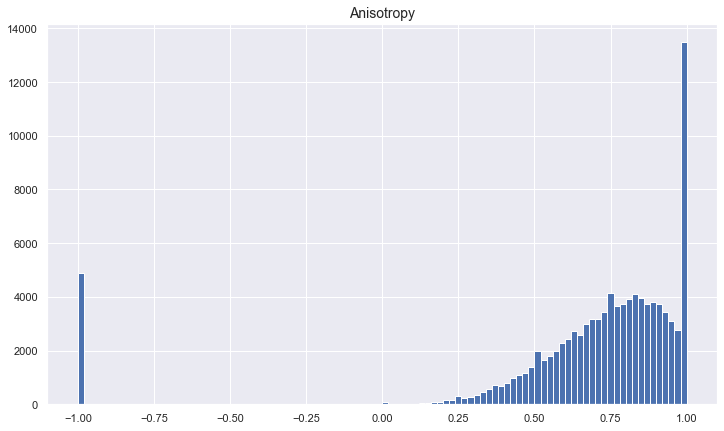

```python
plt.subplots(figsize=(12,7))
plt.hist(all_particles['Anisotropy'], bins=100)
plt.title("Anisotropy", {'size':14})
plt.show()
```

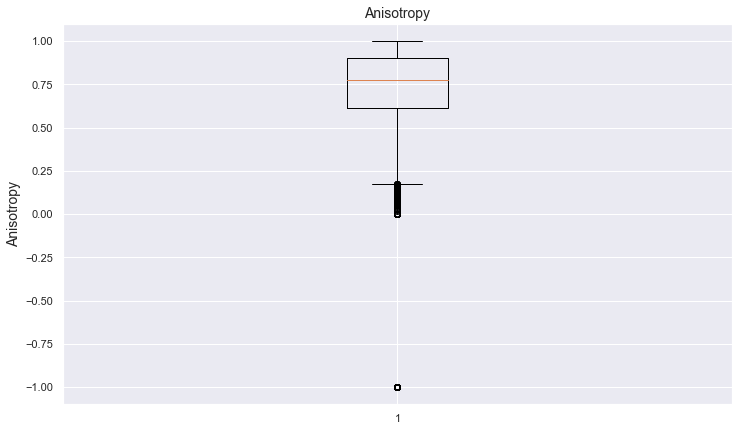

```python
plt.subplots(figsize=(12,7))
plt.boxplot(all_particles['Anisotropy'])
plt.title("Anisotropy", {'size':14})
plt.ylabel("Anisotropy", {'size':14})
plt.show()
```

## Anisotropy: outliers for only particles greater or equal 0 (we're excluding -1 error)

```python
all_anisotropy_greater_or_equal_zero = all_particles[all_particles['Anisotropy'] >= 0]
all_anisotropy_greater_or_equal_zero.describe()
```

|  | Volume3d (mm^3) | BaryCenterX (mm) | BaryCenterY (mm) | BaryCenterZ (mm) | Anisotropy | Elongation | Flatness | VoxelFaceArea (mm^2) | Sphericity |
| --- | --- | --- | --- | --- | --- | --- | --- | --- | --- |
| count | 97641.000000 | 97641.000000 | 97641.000000 | 97641.000000 | 97641.000000 | 97641.000000 | 97641.000000 | 97641.000000 | 97641.000000 |
| mean | 0.010198 | -1246.532057 | -1246.870941 | -1672.358600 | 0.759933 | 0.510370 | 0.394499 | 0.154123 | 0.650660 |
| std | 0.370450 | 4.684911 | 7.815292 | 25.660887 | 0.186381 | 0.255193 | 0.422748 | 1.678523 | 0.074791 |
| min | 0.000007 | -1262.260000 | -1269.460000 | -1731.770000 | 0.000357 | 0.000000 | -1.000000 | 0.002151 | 0.167262 |
| 25% | 0.000061 | -1249.780000 | -1252.480000 | -1691.470000 | 0.638642 | 0.328838 | 0.231038 | 0.010753 | 0.611127 |
| 50% | 0.000190 | -1246.470000 | -1246.850000 | -1672.090000 | 0.785593 | 0.514851 | 0.468186 | 0.024374 | 0.654847 |
| 75% | 0.000665 | -1243.110000 | -1241.300000 | -1653.910000 | 0.911277 | 0.702127 | 0.666637 | 0.059502 | 0.698432 |
| max | 91.752900 | -1233.450000 | -1225.980000 | -1617.670000 | 1.000000 | 0.999980 | 1.000000 | 244.736000 | 0.805997 |

```python
#all_anisotropy_greater_or_equal_zero = all_particles[all_particles['Anisotropy'] >= 0]
q1, q3 = np.percentile(all_anisotropy_greater_or_equal_zero['Anisotropy'],[25,75])
iqr = q3-q1
lower_bound_anis = q1 - (iqr*1.5)
upper_bound_anis = q3 + (iqr*1.5)
print(f"first and third quartile of anisotropy is respectively: {round(q1,3)},{round(q3,3)}")
print(f"interquartile range is {round(iqr,3)}")
print(f"lower boundery {round(lower_bound_anis,3)}")
print(f"upper boundery {round(upper_bound_anis,3)}")
```

```
first and third quartile of anisotropy is respectively: 0.639,0.911
interquartile range is 0.273
lower boundery 0.23
upper boundery 1.32
```

```python
all_particles[(all_particles['Anisotropy'] >= 0) & (all_particles['Anisotropy'] <= lower_bound_anis)].count()
```

```
Volume3d (mm^3)         639
BaryCenterX (mm)        639
BaryCenterY (mm)        639
BaryCenterZ (mm)        639
Anisotropy              639
Elongation              639
Flatness                639
VoxelFaceArea (mm^2)    639
Sphericity              639
SurfaceParticles        639
dtype: int64
```

```python
outliers_anis = all_particles[(all_particles['Anisotropy'] >= 0) & (all_particles['Anisotropy'] <= lower_bound_anis)]
```

### 639 measures particles is possible to classify as outliers, none of them has volume larger than cca 0.05 mm^3 as we can see on the table bellow

```python
outliers_anis.describe()
```

|  | Volume3d (mm^3) | BaryCenterX (mm) | BaryCenterY (mm) | BaryCenterZ (mm) | Anisotropy | Elongation | Flatness | VoxelFaceArea (mm^2) | Sphericity |
| --- | --- | --- | --- | --- | --- | --- | --- | --- | --- |
| count | 639.000000 | 639.000000 | 639.000000 | 639.000000 | 639.000000 | 639.000000 | 639.000000 | 639.000000 | 639.000000 |
| mean | 0.000453 | -1247.089640 | -1246.794632 | -1669.009311 | 0.158825 | 0.918294 | 0.917038 | 0.031566 | 0.690954 |
| std | 0.002499 | 4.128295 | 6.700626 | 27.139355 | 0.070134 | 0.059870 | 0.060629 | 0.067870 | 0.051737 |
| min | 0.000020 | -1259.780000 | -1266.050000 | -1731.770000 | 0.000357 | 0.772649 | 0.774922 | 0.005018 | 0.497892 |
| 25% | 0.000088 | -1249.965000 | -1251.630000 | -1687.515000 | 0.134252 | 0.872870 | 0.871233 | 0.013621 | 0.660155 |
| 50% | 0.000143 | -1247.190000 | -1246.630000 | -1666.090000 | 0.183738 | 0.922325 | 0.918637 | 0.019356 | 0.683645 |
| 75% | 0.000336 | -1244.230000 | -1242.575000 | -1649.145000 | 0.210003 | 0.968570 | 0.972360 | 0.035128 | 0.713761 |
| max | 0.047498 | -1233.830000 | -1227.730000 | -1618.460000 | 0.229658 | 0.999919 | 0.999919 | 1.273900 | 0.805996 |

### another group of extreme particles pose particles with anisotropy over 0.99. This group was designated as such extreme values are not common in nature. This group contains in total 12131 particles with volume not exceeding in any case 0.11 mm^3

```python
all_particles[all_particles['Anisotropy'] > 0.99].describe()
```

|  | Volume3d (mm^3) | BaryCenterX (mm) | BaryCenterY (mm) | BaryCenterZ (mm) | Anisotropy | Elongation | Flatness | VoxelFaceArea (mm^2) | Sphericity |
| --- | --- | --- | --- | --- | --- | --- | --- | --- | --- |
| count | 12131.000000 | 12131.00000 | 12131.000000 | 12131.000000 | 12131.000000 | 12131.000000 | 12131.000000 | 12131.000000 | 12131.000000 |
| mean | 0.000092 | -1246.59827 | -1247.132565 | -1670.965595 | 0.999330 | 0.299124 | -0.431818 | 0.009570 | 0.737280 |
| std | 0.001465 | 4.65141 | 7.930571 | 25.030771 | 0.001967 | 0.368058 | 0.505767 | 0.056697 | 0.063131 |
| min | 0.000007 | -1261.71000 | -1269.400000 | -1727.390000 | 0.990006 | 0.000000 | -1.000000 | 0.002151 | 0.262171 |
| 25% | 0.000014 | -1249.75000 | -1252.930000 | -1688.900000 | 1.000000 | 0.000000 | -1.000000 | 0.003584 | 0.718509 |
| 50% | 0.000014 | -1246.52000 | -1247.250000 | -1670.480000 | 1.000000 | 0.145880 | 0.000000 | 0.003585 | 0.767646 |
| 75% | 0.000027 | -1243.25000 | -1241.470000 | -1652.865000 | 1.000000 | 0.499862 | 0.000000 | 0.006452 | 0.767674 |
| max | 0.105136 | -1233.85000 | -1227.060000 | -1618.400000 | 1.000000 | 0.999919 | 1.000000 | 3.511980 | 0.805997 |

## Elongation: error related to -1 value

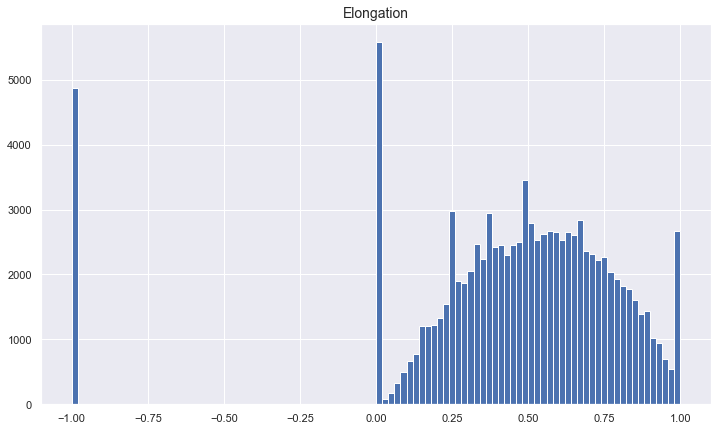

```python
plt.subplots(figsize=(12,7))
plt.hist(all_particles['Elongation'], bins=100)
plt.title("Elongation", {'size':14})
plt.show()
```

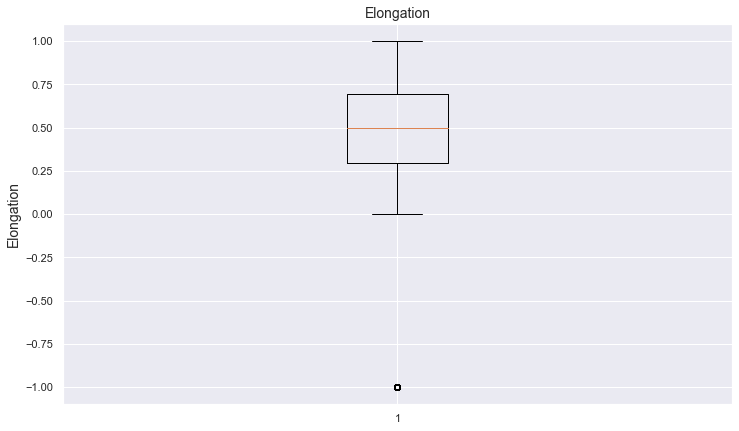

```python
plt.subplots(figsize=(12,7))
plt.boxplot(all_particles['Elongation'])
plt.title("Elongation", {'size':14})
plt.ylabel("Elongation", {'size':14})
plt.show()
```

```python
all_elongation_greater_or_equal_zero = all_particles[all_particles['Elongation'] >= 0]
all_elongation_greater_or_equal_zero.describe()
```

|  | Volume3d (mm^3) | BaryCenterX (mm) | BaryCenterY (mm) | BaryCenterZ (mm) | Anisotropy | Elongation | Flatness | VoxelFaceArea (mm^2) | Sphericity |
| --- | --- | --- | --- | --- | --- | --- | --- | --- | --- |
| count | 97641.000000 | 97641.000000 | 97641.000000 | 97641.000000 | 97641.000000 | 97641.000000 | 97641.000000 | 97641.000000 | 97641.000000 |
| mean | 0.010198 | -1246.532057 | -1246.870941 | -1672.358600 | 0.759933 | 0.510370 | 0.394499 | 0.154123 | 0.650660 |
| std | 0.370450 | 4.684911 | 7.815292 | 25.660887 | 0.186381 | 0.255193 | 0.422748 | 1.678523 | 0.074791 |
| min | 0.000007 | -1262.260000 | -1269.460000 | -1731.770000 | 0.000357 | 0.000000 | -1.000000 | 0.002151 | 0.167262 |
| 25% | 0.000061 | -1249.780000 | -1252.480000 | -1691.470000 | 0.638642 | 0.328838 | 0.231038 | 0.010753 | 0.611127 |
| 50% | 0.000190 | -1246.470000 | -1246.850000 | -1672.090000 | 0.785593 | 0.514851 | 0.468186 | 0.024374 | 0.654847 |
| 75% | 0.000665 | -1243.110000 | -1241.300000 | -1653.910000 | 0.911277 | 0.702127 | 0.666637 | 0.059502 | 0.698432 |
| max | 91.752900 | -1233.450000 | -1225.980000 | -1617.670000 | 1.000000 | 0.999980 | 1.000000 | 244.736000 | 0.805997 |

```python
all_anisotropy_greater_or_equal_zero = all_particles[all_particles['Anisotropy'] >= 0]
q1, q3 = np.percentile(all_elongation_greater_or_equal_zero['Elongation'],[25,75])
iqr = q3-q1
lower_bound_elong = q1 - (iqr*1.5)
upper_bound_elong = q3 + (iqr*1.5)
print(f"first and third quartile of elongation is respectively: {round(q1,3)},{round(q3,3)}")
print(f"interquartile range is {round(iqr,3)}")
print(f"lower boundery {round(lower_bound_elong,3)}")
print(f"upper boundery {round(upper_bound_elong,3)}")
```

```
first and third quartile of elongation is respectively: 0.329,0.702
interquartile range is 0.373
lower boundery -0.231
upper boundery 1.262
```

```python
all_particles[all_particles['Elongation'] > 0.99].describe()
```

|  | Volume3d (mm^3) | BaryCenterX (mm) | BaryCenterY (mm) | BaryCenterZ (mm) | Anisotropy | Elongation | Flatness | VoxelFaceArea (mm^2) | Sphericity |
| --- | --- | --- | --- | --- | --- | --- | --- | --- | --- |
| count | 2448.000000 | 2448.000000 | 2448.000000 | 2448.000000 | 2448.000000 | 2448.000000 | 2.448000e+03 | 2448.000000 | 2448.000000 |
| mean | 0.000060 | -1246.246115 | -1246.621209 | -1679.811965 | 0.868287 | 0.999442 | 1.319469e-01 | 0.008712 | 0.739462 |
| std | 0.000376 | 4.627942 | 7.806308 | 25.283675 | 0.270040 | 0.001683 | 2.704529e-01 | 0.017600 | 0.047757 |
| min | 0.000020 | -1259.680000 | -1267.780000 | -1731.770000 | 0.000357 | 0.990079 | 0.000000e+00 | 0.005018 | 0.368915 |
| 25% | 0.000027 | -1249.455000 | -1252.432500 | -1699.995000 | 1.000000 | 0.999919 | 0.000000e+00 | 0.005735 | 0.751931 |
| 50% | 0.000027 | -1246.140000 | -1246.050000 | -1679.975000 | 1.000000 | 0.999919 | 0.000000e+00 | 0.005735 | 0.761639 |
| 75% | 0.000034 | -1242.730000 | -1240.800000 | -1663.135000 | 1.000000 | 0.999919 | 1.487107e-18 | 0.007886 | 0.761639 |
| max | 0.014503 | -1234.290000 | -1226.630000 | -1619.070000 | 1.000000 | 0.999980 | 9.999190e-01 | 0.645194 | 0.805996 |

```python
all_particles[(all_particles['Elongation'] == 0)].describe()
```

|  | Volume3d (mm^3) | BaryCenterX (mm) | BaryCenterY (mm) | BaryCenterZ (mm) | Anisotropy | Elongation | Flatness | VoxelFaceArea (mm^2) | Sphericity |
| --- | --- | --- | --- | --- | --- | --- | --- | --- | --- |
| count | 5321.000000 | 5321.000000 | 5321.000000 | 5321.000000 | 5321.0 | 5321.0 | 5321.0 | 5321.000000 | 5321.000000 |
| mean | 0.000012 | -1246.579662 | -1247.005867 | -1669.563665 | 1.0 | 0.0 | -1.0 | 0.003249 | 0.776492 |
| std | 0.000003 | 4.658488 | 7.802581 | 25.008608 | 0.0 | 0.0 | 0.0 | 0.000671 | 0.018467 |
| min | 0.000007 | -1261.710000 | -1269.400000 | -1726.910000 | 1.0 | 0.0 | -1.0 | 0.002151 | 0.642756 |
| 25% | 0.000014 | -1249.750000 | -1252.700000 | -1686.240000 | 1.0 | 0.0 | -1.0 | 0.003584 | 0.767667 |
| 50% | 0.000014 | -1246.470000 | -1246.980000 | -1668.540000 | 1.0 | 0.0 | -1.0 | 0.003584 | 0.767674 |
| 75% | 0.000014 | -1243.250000 | -1241.590000 | -1651.570000 | 1.0 | 0.0 | -1.0 | 0.003584 | 0.767674 |
| max | 0.000034 | -1234.220000 | -1227.060000 | -1618.530000 | 1.0 | 0.0 | -1.0 | 0.007886 | 0.805997 |

## Flatness

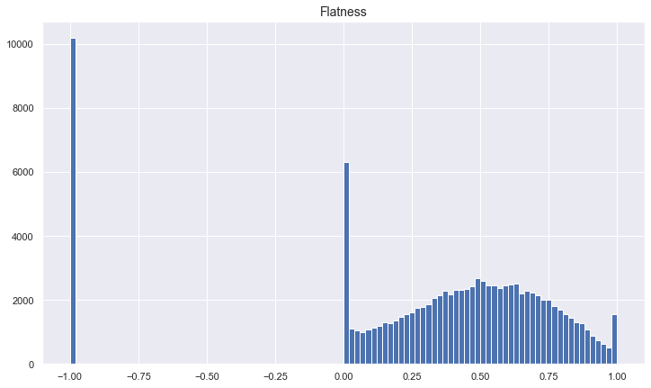

```python
plt.subplots(figsize=(12,7))
plt.hist(all_particles['Flatness'], bins=100)
plt.title("Flatness", {'size':14})
plt.show()
```

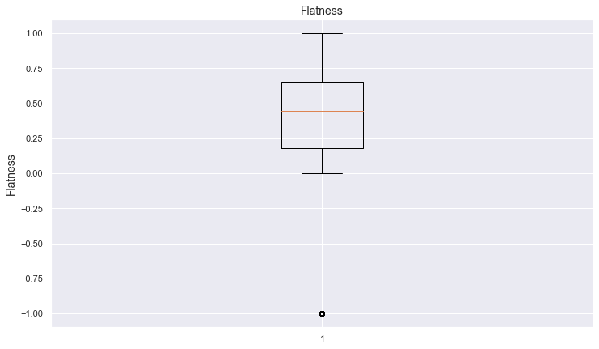

```python
plt.subplots(figsize=(12,7))
plt.boxplot(all_particles['Flatness'])
plt.title("Flatness", {'size':14})
plt.ylabel("Flatness", {'size':14})
plt.show()
```

```python
10195/all_particles.shape[0]
```

```
0.09944886114227186
```

### total number of 10195 particles has flatness equal to -1, which accounts for 9.9% of all particles. None of these particles has volume greater than 0.000034 mm^3

```python
all_particles[all_particles['Flatness'] == -1].describe()
```

|  | Volume3d (mm^3) | BaryCenterX (mm) | BaryCenterY (mm) | BaryCenterZ (mm) | Anisotropy | Elongation | Flatness | VoxelFaceArea (mm^2) | Sphericity |
| --- | --- | --- | --- | --- | --- | --- | --- | --- | --- |
| count | 10195.000000 | 10195.000000 | 10195.000000 | 10195.00000 | 10195.000000 | 10195.000000 | 10195.0 | 10195.000000 | 10195.000000 |
| mean | 0.000009 | -1246.465640 | -1246.864800 | -1672.68767 | 0.043845 | -0.478077 | -1.0 | 0.002724 | 0.790598 |
| std | 0.000003 | 4.704894 | 7.958192 | 24.89639 | 0.999087 | 0.499544 | 0.0 | 0.000732 | 0.019880 |
| min | 0.000007 | -1261.710000 | -1269.400000 | -1727.69000 | -1.000000 | -1.000000 | -1.0 | 0.002151 | 0.642756 |
| 25% | 0.000007 | -1249.770000 | -1252.720000 | -1690.56000 | -1.000000 | -1.000000 | -1.0 | 0.002151 | 0.767674 |
| 50% | 0.000007 | -1246.400000 | -1246.810000 | -1673.16000 | 1.000000 | 0.000000 | -1.0 | 0.002151 | 0.805997 |
| 75% | 0.000014 | -1243.100000 | -1241.230000 | -1655.07000 | 1.000000 | 0.000000 | -1.0 | 0.003584 | 0.805997 |
| max | 0.000034 | -1233.730000 | -1227.060000 | -1618.21000 | 1.000000 | 0.000000 | -1.0 | 0.007886 | 0.805997 |

### Outliers flatness

```python
all_flatness_greater_or_equal_zero = all_particles[all_particles['Flatness'] >= 0]
q1, q3 = np.percentile(all_flatness_greater_or_equal_zero['Flatness'],[25,75])
iqr = q3-q1
lower_bound_flat = q1 - (iqr*1.5)
upper_bound_flat = q3 + (iqr*1.5)
print(f"first and third quartile of flatness is respectively: {round(q1,3)},{round(q3,3)}")
print(f"interquartile range is {round(iqr,3)}")
print(f"lower boundery {round(lower_bound_flat,3)}")
print(f"upper boundery {round(upper_bound_flat,3)}")
```

```
first and third quartile of flatness is respectively: 0.279,0.678
interquartile range is 0.399
lower boundery -0.32
upper boundery 1.277
```

```python
all_particles[all_particles['Flatness'] > 0.99].describe()
```

|  | Volume3d (mm^3) | BaryCenterX (mm) | BaryCenterY (mm) | BaryCenterZ (mm) | Anisotropy | Elongation | Flatness | VoxelFaceArea (mm^2) | Sphericity |
| --- | --- | --- | --- | --- | --- | --- | --- | --- | --- |
| count | 1389.000000 | 1389.000000 | 1389.000000 | 1389.000000 | 1389.000000 | 1.389000e+03 | 1389.000000 | 1389.000000 | 1389.000000 |
| mean | 0.000098 | -1246.998481 | -1247.555421 | -1662.932801 | 0.569663 | 4.306377e-01 | 0.999433 | 0.010770 | 0.753231 |
| std | 0.001314 | 4.681317 | 7.127523 | 24.741036 | 0.210028 | 2.102938e-01 | 0.001648 | 0.042201 | 0.058937 |
| min | 0.000020 | -1261.910000 | -1266.040000 | -1731.770000 | 0.000357 | 1.210050e-10 | 0.990036 | 0.005018 | 0.415437 |
| 25% | 0.000027 | -1250.120000 | -1252.590000 | -1676.390000 | 0.500179 | 2.499310e-01 | 0.999919 | 0.005735 | 0.705819 |
| 50% | 0.000054 | -1246.730000 | -1247.500000 | -1661.160000 | 0.500179 | 4.998620e-01 | 0.999919 | 0.008603 | 0.761639 |
| 75% | 0.000054 | -1243.680000 | -1242.640000 | -1644.730000 | 0.750089 | 4.998620e-01 | 0.999919 | 0.010037 | 0.805996 |
| max | 0.048890 | -1233.870000 | -1226.950000 | -1617.810000 | 1.000000 | 9.997240e-01 | 1.000000 | 1.556410 | 0.805996 |

```python
all_particles[(all_particles['Flatness'] >= 0) & (all_particles['Flatness'] <= 0.01)].describe()
```

|  | Volume3d (mm^3) | BaryCenterX (mm) | BaryCenterY (mm) | BaryCenterZ (mm) | Anisotropy | Elongation | Flatness | VoxelFaceArea (mm^2) | Sphericity |
| --- | --- | --- | --- | --- | --- | --- | --- | --- | --- |
| count | 5753.000000 | 5753.000000 | 5753.000000 | 5753.000000 | 5753.000000 | 5.753000e+03 | 5753.000000 | 5753.000000 | 5753.000000 |
| mean | 0.000058 | -1246.577118 | -1247.132955 | -1672.737575 | 0.999669 | 5.842601e-01 | 0.000547 | 0.008759 | 0.718875 |
| std | 0.000196 | 4.646412 | 8.106918 | 24.896431 | 0.001156 | 3.385296e-01 | 0.001788 | 0.016144 | 0.055903 |
| min | 0.000014 | -1261.390000 | -1268.280000 | -1727.390000 | 0.991118 | 1.195290e-21 | 0.000000 | 0.003584 | 0.282228 |
| 25% | 0.000027 | -1249.700000 | -1253.090000 | -1690.820000 | 1.000000 | 2.499310e-01 | 0.000000 | 0.005735 | 0.677008 |
| 50% | 0.000027 | -1246.480000 | -1247.310000 | -1672.880000 | 1.000000 | 4.998620e-01 | 0.000000 | 0.005735 | 0.761605 |
| 75% | 0.000041 | -1243.190000 | -1241.150000 | -1654.890000 | 1.000000 | 9.999190e-01 | 0.000000 | 0.007886 | 0.761639 |
| max | 0.005293 | -1233.880000 | -1227.170000 | -1618.400000 | 1.000000 | 9.999190e-01 | 0.009997 | 0.520447 | 0.767674 |

## volume related error 0.000006786470 mm^3

```python
val = particles_sphericity['Volume3d (mm^3) '].iloc[-1]
error_format = format(val, '.12f')
print(error_format)
```

```
0.000006786470
```

```python
vol_errors = particles_sphericity[particles_sphericity['Volume3d (mm^3) '] == val]
```

### in total this group contains 6204 particles, all of them has flatness equal to -1

```python
vol_errors.describe()
```

|  | Volume3d (mm^3) | BaryCenterX (mm) | BaryCenterY (mm) | BaryCenterZ (mm) | Anisotropy | Elongation | Flatness | VoxelFaceArea (mm^2) | Sphericity |
| --- | --- | --- | --- | --- | --- | --- | --- | --- | --- |
| count | 6.204000e+03 | 6204.000000 | 6204.000000 | 6204.000000 | 6204.000000 | 6204.000000 | 6204.0 | 6.204000e+03 | 6.204000e+03 |
| mean | 6.786470e-06 | -1246.517265 | -1247.046449 | -1670.298515 | -0.571244 | -0.785622 | -1.0 | 2.150700e-03 | 8.059973e-01 |
| std | 5.726404e-19 | 4.663361 | 7.841838 | 24.982039 | 0.820846 | 0.410423 | 0.0 | 2.567598e-16 | 6.839525e-14 |
| min | 6.786470e-06 | -1261.200000 | -1268.700000 | -1727.690000 | -1.000000 | -1.000000 | -1.0 | 2.150700e-03 | 8.059973e-01 |
| 25% | 6.786470e-06 | -1249.770000 | -1252.755000 | -1686.840000 | -1.000000 | -1.000000 | -1.0 | 2.150700e-03 | 8.059973e-01 |
| 50% | 6.786470e-06 | -1246.440000 | -1247.140000 | -1670.260000 | -1.000000 | -1.000000 | -1.0 | 2.150700e-03 | 8.059973e-01 |
| 75% | 6.786470e-06 | -1243.200000 | -1241.400000 | -1652.095000 | -1.000000 | -1.000000 | -1.0 | 2.150700e-03 | 8.059973e-01 |
| max | 6.786470e-06 | -1233.730000 | -1227.140000 | -1618.210000 | 1.000000 | 0.000000 | -1.0 | 2.150700e-03 | 8.059973e-01 |

### volume error aggerate stats

```python
vol_errors.groupby('Volume3d (mm^3) ').mean()
```

| Volume3d (mm^3) | BaryCenterX (mm) | BaryCenterY (mm) | BaryCenterZ (mm) | Anisotropy | Elongation | Flatness | VoxelFaceArea (mm^2) | Sphericity |
| --- | --- | --- | --- | --- | --- | --- | --- | --- |
| 0.000007 | -1246.517265 | -1247.046449 | -1670.298515 | -0.571244 | -0.785622 | -1.0 | 0.002151 | 0.805997 |

# 2. Errors: inner vs surface particles

## we distinguish between inner and surface particles using SurfaceParticle feature. Surface particles can be generated out of this dataset by using e.g. convex hull algorithm.

# Inner particles

```python
inner_particles = all_particles[all_particles['SurfaceParticles'] == False]
```

```python
inner_particles.describe()
```

|  | Volume3d (mm^3) | BaryCenterX (mm) | BaryCenterY (mm) | BaryCenterZ (mm) | Anisotropy | Elongation | Flatness | VoxelFaceArea (mm^2) | Sphericity |
| --- | --- | --- | --- | --- | --- | --- | --- | --- | --- |
| count | 102284.000000 | 102284.000000 | 102284.000000 | 102284.000000 | 102284.000000 | 102284.000000 | 102284.000000 | 102284.000000 | 102284.000000 |
| mean | 0.009727 | -1246.524316 | -1246.864102 | -1672.570730 | 0.676229 | 0.438554 | 0.328105 | 0.147000 | 0.658048 |
| std | 0.361949 | 4.680952 | 7.823634 | 25.563554 | 0.416450 | 0.406696 | 0.508196 | 1.640213 | 0.080130 |
| min | 0.000007 | -1262.120000 | -1269.120000 | -1728.380000 | -1.000000 | -1.000000 | -1.000000 | 0.002151 | 0.167262 |
| 25% | 0.000048 | -1249.780000 | -1252.500000 | -1691.640000 | 0.611290 | 0.292920 | 0.179908 | 0.009320 | 0.614133 |
| 50% | 0.000170 | -1246.460000 | -1246.850000 | -1672.420000 | 0.772416 | 0.499862 | 0.447838 | 0.022224 | 0.659861 |
| 75% | 0.000611 | -1243.110000 | -1241.280000 | -1654.220000 | 0.904543 | 0.692425 | 0.655682 | 0.055918 | 0.707018 |
| max | 91.752900 | -1233.630000 | -1226.560000 | -1617.760000 | 1.000000 | 0.999980 | 1.000000 | 244.736000 | 0.805997 |

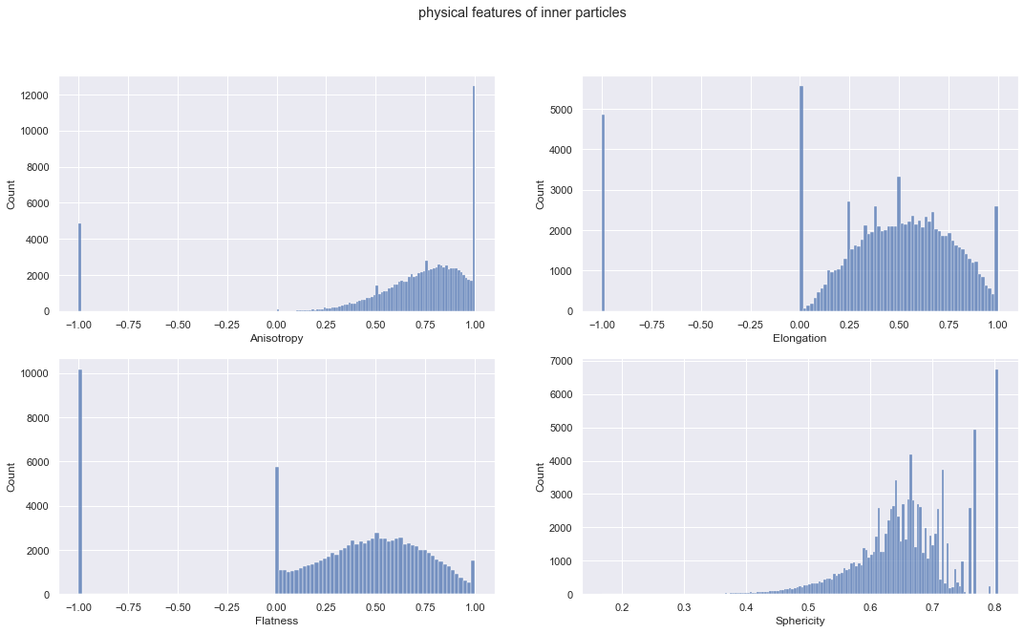

```python
fig, axes = plt.subplots(2, 2, figsize=(18, 10))

fig.suptitle('physical features of inner particles')

sns.histplot(ax=axes[0, 0], data=inner_particles, x='Anisotropy')
sns.histplot(ax=axes[0, 1], data=inner_particles, x='Elongation')
sns.histplot(ax=axes[1, 0], data=inner_particles, x='Flatness')
sns.histplot(ax=axes[1, 1], data=inner_particles, x='Sphericity')
```

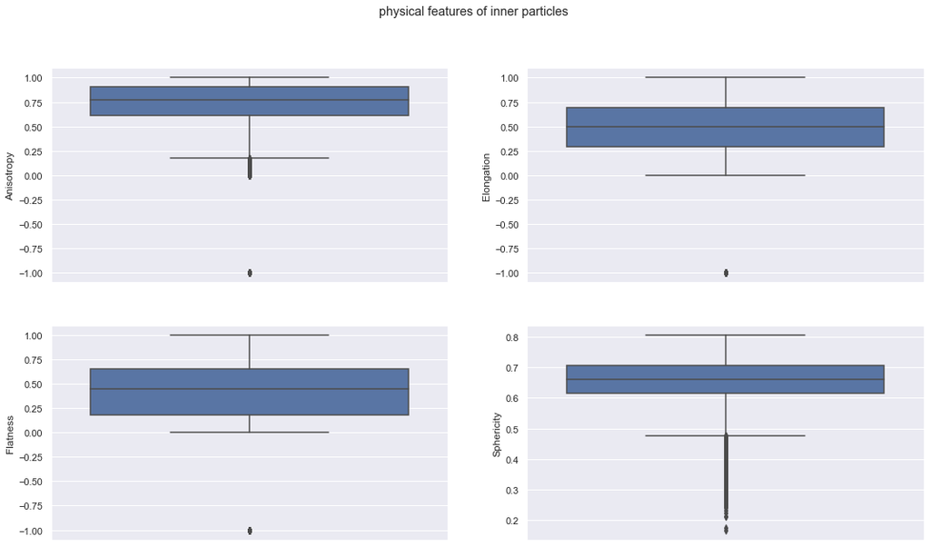

```python
fig, axes = plt.subplots(2, 2, figsize=(18, 10))

fig.suptitle('physical features of inner particles')

sns.boxplot(ax=axes[0, 0], data=inner_particles, y='Anisotropy')
sns.boxplot(ax=axes[0, 1], data=inner_particles, y='Elongation')
sns.boxplot(ax=axes[1, 0], data=inner_particles, y='Flatness')
sns.boxplot(ax=axes[1, 1], data=inner_particles, y='Sphericity')
```

## Surface particles

```python
surface_particles = all_particles[all_particles['SurfaceParticles'] == True]
```

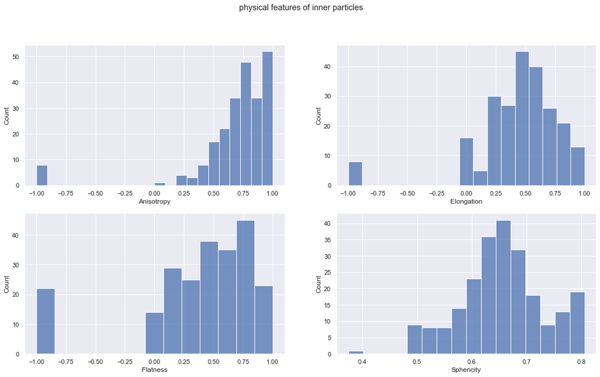

```python
fig, axes = plt.subplots(2, 2, figsize=(18, 10))

fig.suptitle('physical features of inner particles')

sns.histplot(ax=axes[0, 0], data=surface_particles, x='Anisotropy')
sns.histplot(ax=axes[0, 1], data=surface_particles, x='Elongation')
sns.histplot(ax=axes[1, 0], data=surface_particles, x='Flatness')
sns.histplot(ax=axes[1, 1], data=surface_particles, x='Sphericity')
```

```python
surface_particles.describe()
```

|  | Volume3d (mm^3) | BaryCenterX (mm) | BaryCenterY (mm) | BaryCenterZ (mm) | Anisotropy | Elongation | Flatness | VoxelFaceArea (mm^2) | Sphericity |
| --- | --- | --- | --- | --- | --- | --- | --- | --- | --- |
| count | 231.000000 | 231.000000 | 231.000000 | 231.000000 | 231.000000 | 231.000000 | 231.000000 | 231.000000 | 231.000000 |
| mean | 0.003468 | -1245.931775 | -1246.520130 | -1657.333723 | 0.689307 | 0.441536 | 0.369695 | 0.101654 | 0.656812 |
| std | 0.022433 | 7.232970 | 10.356503 | 38.824358 | 0.370539 | 0.366199 | 0.514710 | 0.360958 | 0.079194 |
| min | 0.000007 | -1262.260000 | -1269.460000 | -1731.770000 | -1.000000 | -1.000000 | -1.000000 | 0.002151 | 0.374310 |
| 25% | 0.000068 | -1250.235000 | -1252.070000 | -1681.015000 | 0.611565 | 0.289645 | 0.215293 | 0.011470 | 0.614880 |
| 50% | 0.000183 | -1245.530000 | -1245.390000 | -1646.600000 | 0.763584 | 0.486717 | 0.493768 | 0.023657 | 0.655727 |
| 75% | 0.000699 | -1240.360000 | -1241.015000 | -1620.610000 | 0.900506 | 0.653838 | 0.713386 | 0.063088 | 0.700329 |
| max | 0.305269 | -1233.450000 | -1225.980000 | -1617.670000 | 1.000000 | 0.999919 | 1.000000 | 4.460620 | 0.805997 |

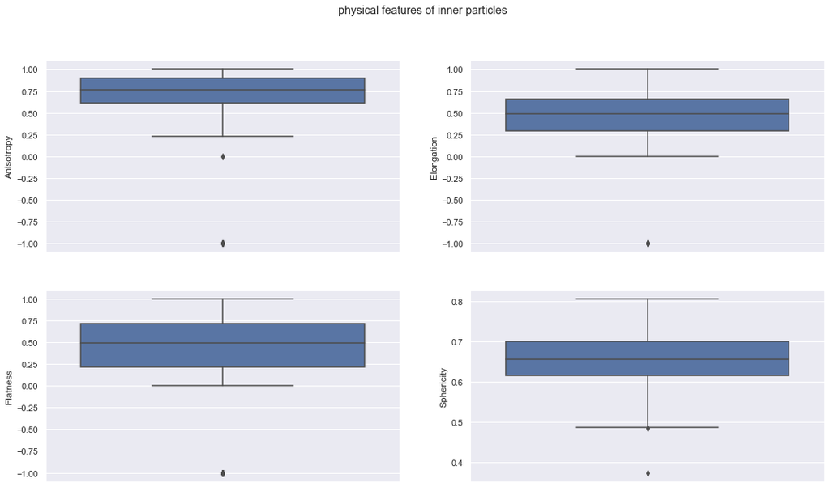

```python
fig, axes = plt.subplots(2, 2, figsize=(18, 10))

fig.suptitle('physical features of inner particles')

sns.boxplot(ax=axes[0, 0], data=surface_particles, y='Anisotropy')
sns.boxplot(ax=axes[0, 1], data=surface_particles, y='Elongation')
sns.boxplot(ax=axes[1, 0], data=surface_particles, y='Flatness')
sns.boxplot(ax=axes[1, 1], data=surface_particles, y='Sphericity')
```

# just based on the charts above we see that errors occur in both surface and inner area